# Brauchle_HW2

3a. Provided the GPA is high enough, males earn more on average than women.  
3b. (Salary) = 50 + 20 * 4.0 + 0.07 * 110 + 35 + 0.01 * (4.0*110) - 10* (4.0) = 137.1  
3c. False, because we would need information on the standard error of the interaction to find a probability of the hypothesis $\beta_{i}$ = 0.

```r
#8a i - iii
auto_slm <- lm(mpg ~ horsepower, data = Auto)
summary(auto_slm)
```

```
##
## Call:
## lm(formula = mpg ~ horsepower, data = Auto)
##
## Residuals:
##      Min       1Q   Median       3Q      Max
## -13.5710  -3.2592  -0.3435   2.7630  16.9240
##
## Coefficients:
##              Estimate Std. Error t value Pr(>|t|)
## (Intercept) 39.935861   0.717499   55.66   <2e-16 ***
## horsepower  -0.157845   0.006446  -24.49   <2e-16 ***
## ---
## Signif. codes:  0 '***' 0.001 '**' 0.01 '*' 0.05 '.' 0.1 ' ' 1
##
## Residual standard error: 4.906 on 390 degrees of freedom
##   (5 observations deleted due to missingness)
## Multiple R-squared:  0.6059, Adjusted R-squared:  0.6049
## F-statistic: 599.7 on 1 and 390 DF,  p-value: < 2.2e-16
```

```r
#8aiv
predict (auto_slm ,data.frame(horsepower = 98), interval="confidence")
```

```
##        fit      lwr      upr
## 1 24.46708 23.97308 24.96108
```

```r
predict (auto_slm ,data.frame(horsepower = 98), interval="prediction")
```

```
##        fit     lwr      upr
## 1 24.46708 14.8094 34.12476
```

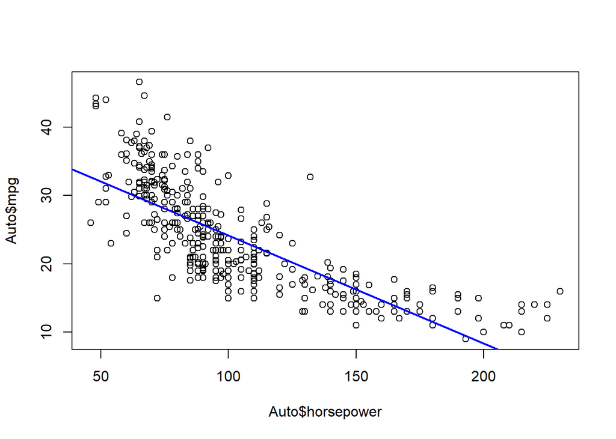

```r
#8b
plot(Auto$horsepower, Auto$mpg)
abline(auto_slm, lwd = 2, col = "blue")
```

8b. A line fits the data pretty well, but we do see the data curve at high values of horsepower.

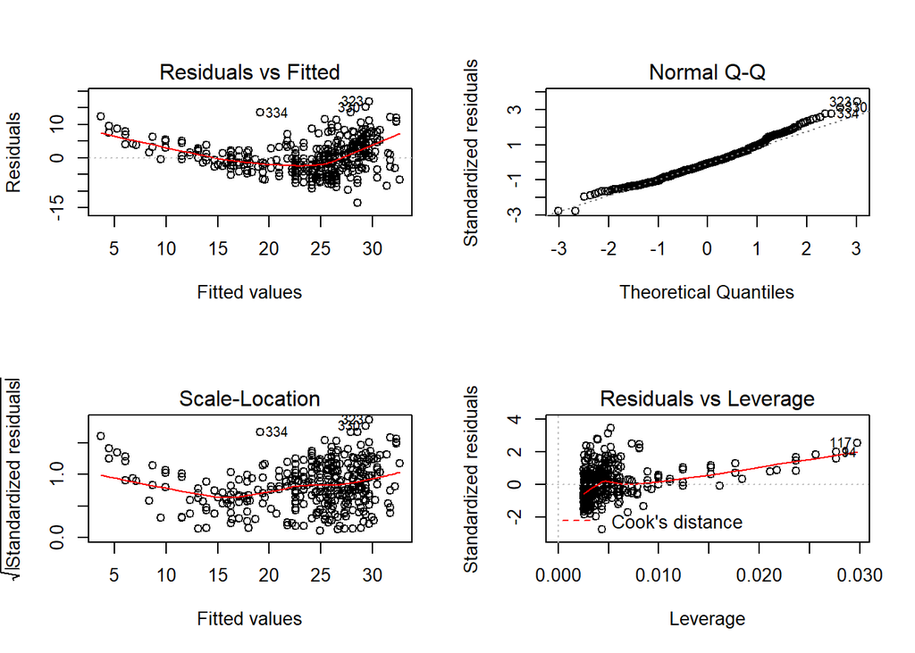

```r
#8c
par(mfrow=c(2,2))
plot(auto_slm)
```

8c. The residuals v fitted plot shows funneling and a curvilinear pattern. There also appear to be observations with a significant pull, particularly observation 117, based on the residuals vs. leverage plot.

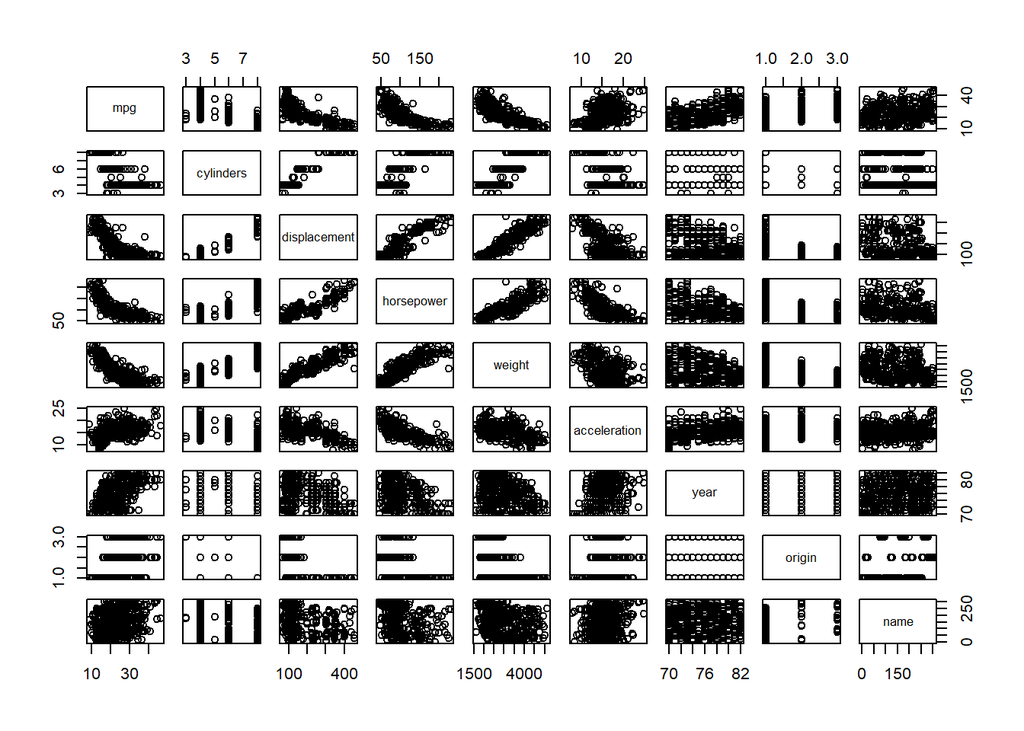

```r
#9a

pairs(Auto)
```

9a. There appears to be relationships between mpg and displacement, horsepower, and weight. They appear to be mostly linear, but with a slight curve.

```r
#9b
auto_noname <- Auto %>% dplyr::select(-name)
cor(auto_noname, use = "complete.obs")
```

```
##                     mpg  cylinders displacement horsepower     weight
## mpg           1.0000000 -0.7776175   -0.8051269 -0.7784268 -0.8322442
## cylinders    -0.7776175  1.0000000    0.9508233  0.8429834  0.8975273
## displacement -0.8051269  0.9508233    1.0000000  0.8972570  0.9329944
## horsepower   -0.7784268  0.8429834    0.8972570  1.0000000  0.8645377
## weight       -0.8322442  0.8975273    0.9329944  0.8645377  1.0000000
## acceleration  0.4233285 -0.5046834   -0.5438005 -0.6891955 -0.4168392
## year          0.5805410 -0.3456474   -0.3698552 -0.4163615 -0.3091199
## origin        0.5652088 -0.5689316   -0.6145351 -0.4551715 -0.5850054
##              acceleration       year     origin
## mpg             0.4233285  0.5805410  0.5652088
## cylinders      -0.5046834 -0.3456474 -0.5689316
## displacement   -0.5438005 -0.3698552 -0.6145351
## horsepower     -0.6891955 -0.4163615 -0.4551715
## weight         -0.4168392 -0.3091199 -0.5850054
## acceleration    1.0000000  0.2903161  0.2127458
## year            0.2903161  1.0000000  0.1815277
## origin          0.2127458  0.1815277  1.0000000
```

9b. Considering |r| > 0.8 as having a strong linear relationship, mpg has a strong linear relationship with displacement and weight. Similarly, cylinders also has a strong linear relationship with displacement, horsepower, and weight. Displacement also has a strong relationship with horsepower and weight. Horsepower also has a strong relationship with weight.

```r
#9c
all_auto_lm <- lm(mpg ~ cylinders + displacement + horsepower + weight + acceleration + year + origin, data = Auto)
summary(all_auto_lm)
```

```
##
## Call:
## lm(formula = mpg ~ cylinders + displacement + horsepower + weight +
##     acceleration + year + origin, data = Auto)
##
## Residuals:
##     Min      1Q  Median      3Q     Max
## -9.5903 -2.1565 -0.1169  1.8690 13.0604
##
## Coefficients:
##                Estimate Std. Error t value Pr(>|t|)
## (Intercept)  -17.218435   4.644294  -3.707  0.00024 ***
## cylinders     -0.493376   0.323282  -1.526  0.12780
## displacement   0.019896   0.007515   2.647  0.00844 **
## horsepower    -0.016951   0.013787  -1.230  0.21963
## weight        -0.006474   0.000652  -9.929  < 2e-16 ***
## acceleration   0.080576   0.098845   0.815  0.41548
## year           0.750773   0.050973  14.729  < 2e-16 ***
## origin         1.426141   0.278136   5.127 4.67e-07 ***
## ---
## Signif. codes:  0 '***' 0.001 '**' 0.01 '*' 0.05 '.' 0.1 ' ' 1
##
## Residual standard error: 3.328 on 384 degrees of freedom
##   (5 observations deleted due to missingness)
## Multiple R-squared:  0.8215, Adjusted R-squared:  0.8182
## F-statistic: 252.4 on 7 and 384 DF,  p-value: < 2.2e-16
```

9c. i. The overall model is significant (F = 252.4, p << 0.05), and it has a high Adjusted R-squared of 81.82%. Therefore, the predictors appear to have a strong linear relationship with mpg.  
ii. Displacement, Weight, Year, and Origin appear to have a significant linear relationship with mpg.  
iii. For every one year, mpg increased by 0.751 mpg.

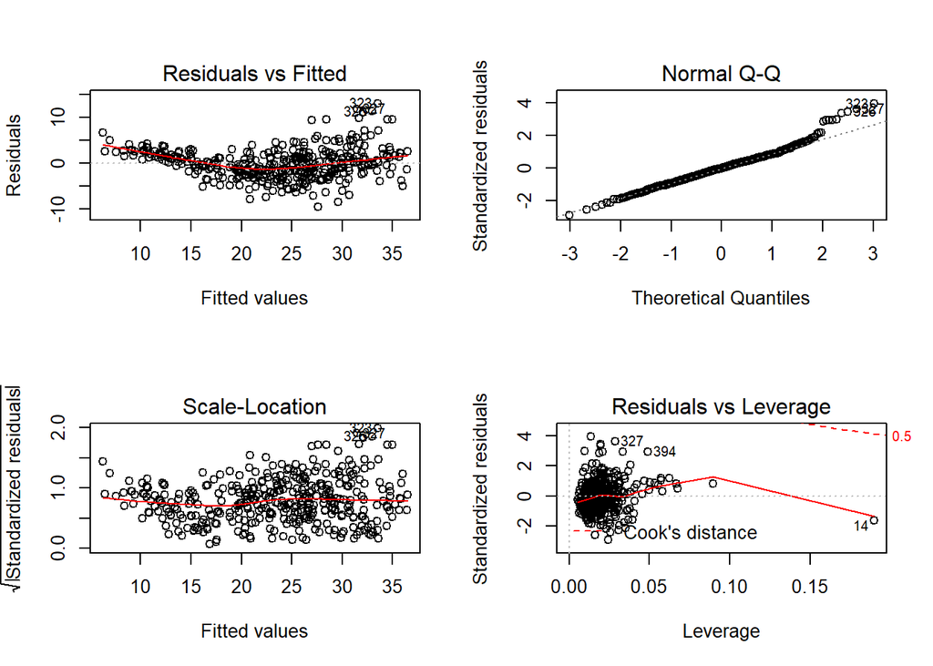

```r
#9d
par(mfrow=c(2,2))
plot(all_auto_lm)
```

9d. The Residuals vs Fitted plot shows that the relationship does appear to have a curvilinear pattern, and the leverage plot points to observation 14 as having unusually high leverage.

```r
int_model_1 <- lm(mpg ~ cylinders + displacement + horsepower + weight + acceleration + year + origin + cylinders:weight + displacement*weight, data = Auto)
summary(int_model_1)
```

```
##
## Call:
## lm(formula = mpg ~ cylinders + displacement + horsepower + weight +
##     acceleration + year + origin + cylinders:weight + displacement *
##     weight, data = Auto)
##
## Residuals:
##     Min      1Q  Median      3Q     Max
## -9.8292 -1.8274 -0.1202  1.6231 12.1608
##
## Coefficients:
##                       Estimate Std. Error t value Pr(>|t|)
## (Intercept)         -6.360e+00  6.038e+00  -1.053 0.292864
## cylinders            4.592e-01  1.519e+00   0.302 0.762535
## displacement        -7.319e-02  2.374e-02  -3.083 0.002195 **
## horsepower          -3.274e-02  1.240e-02  -2.640 0.008619 **
## weight              -1.031e-02  1.631e-03  -6.320 7.31e-10 ***
## acceleration         6.511e-02  8.864e-02   0.735 0.463044
## year                 7.851e-01  4.559e-02  17.223  < 2e-16 ***
## origin               5.530e-01  2.649e-01   2.088 0.037488 *
## cylinders:weight    -1.016e-04  4.429e-04  -0.229 0.818721
## displacement:weight  2.401e-05  6.152e-06   3.902 0.000113 ***
## ---
## Signif. codes:  0 '***' 0.001 '**' 0.01 '*' 0.05 '.' 0.1 ' ' 1
##
## Residual standard error: 2.967 on 382 degrees of freedom
##   (5 observations deleted due to missingness)
## Multiple R-squared:  0.8588, Adjusted R-squared:  0.8554
## F-statistic: 258.1 on 9 and 382 DF,  p-value: < 2.2e-16
```

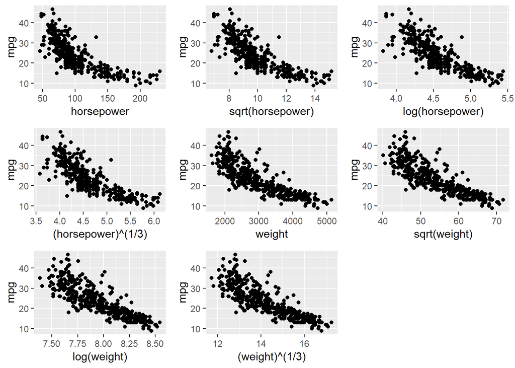

```r
p1 <- Auto %>% ggplot(aes(horsepower, mpg)) + geom_point()
p2 <- Auto %>% ggplot(aes(sqrt(horsepower), mpg)) + geom_point()
p3 <- Auto %>% ggplot(aes(log(horsepower), mpg)) + geom_point()
p4 <- Auto %>% ggplot(aes((horsepower)^(1/3), mpg)) + geom_point()

p5 <- Auto %>% ggplot(aes(weight, mpg)) + geom_point()
p6 <- Auto %>% ggplot(aes(sqrt(weight), mpg)) + geom_point()
p7 <- Auto %>% ggplot(aes(log(weight), mpg)) + geom_point()
p8 <- Auto %>% ggplot(aes((weight)^(1/3), mpg)) + geom_point()

grid.arrange(p1, p2, p3, p4, p5, p6, p7, p8)
```

9f. From the plots above we see that a log transformation of horsepower and a cuberoot transformation of weight would make the data the most linear.

```r
#14a
set.seed(1)
x1=runif (100)
x2=0.5*x1+rnorm (100)/10
y=2+2*x1+0.3*x2+rnorm (100)
```

14a. The form of the linear model is $Y=2+2X_{1}+0.3X_{2}+ \epsilon$, where $\epsilon$ ~ N(0,1). The correlation coefficients are as follows: $\beta_{0}$ = 2, $\beta_{1}$ = 2, $\beta_{2}$ = 0.3.

```r
# 14b
cor(x1, x2)
```

```
## [1] 0.8351212
```

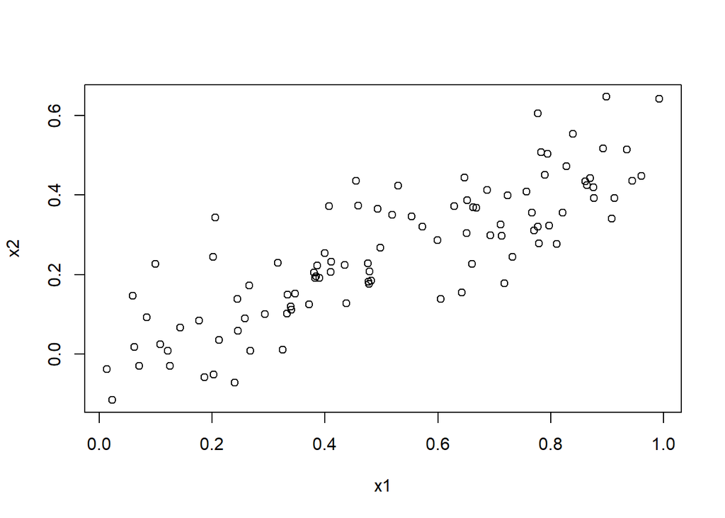

```r
plot(x1, x2)
```

14b. $X_{1}$ and $X_{2}$ have a correlation of 0.835, and the scatterplot confirms a strong, positive linear trend.

```r
#14c
col_lm <- lm(y ~ x1 + x2)
summary(col_lm)
```

```
##
## Call:
## lm(formula = y ~ x1 + x2)
##
## Residuals:
##     Min      1Q  Median      3Q     Max
## -2.8311 -0.7273 -0.0537  0.6338  2.3359
##
## Coefficients:
##             Estimate Std. Error t value Pr(>|t|)
## (Intercept)   2.1305     0.2319   9.188 7.61e-15 ***
## x1            1.4396     0.7212   1.996   0.0487 *
## x2            1.0097     1.1337   0.891   0.3754
## ---
## Signif. codes:  0 '***' 0.001 '**' 0.01 '*' 0.05 '.' 0.1 ' ' 1
##
## Residual standard error: 1.056 on 97 degrees of freedom
## Multiple R-squared:  0.2088, Adjusted R-squared:  0.1925
## F-statistic:  12.8 on 2 and 97 DF,  p-value: 1.164e-05
```

14c. $\hat{B_{0}}$ = 2.13, $\hat{B_{1}}$ = 1.44, and $\hat{B_{0}}$ = 1.01, which is quite different from the true values. The null hypothesis $\beta_{1} = 0$ can be rejected (t = 1.996, p < 0.05). However, the null hypothesis $\beta_{2} = 0$ can not be rejected (t = 0.891, p > 0.05).

```r
#14d
col_lm_2 <- lm(y ~ x1)
summary(col_lm_2)
```

```
##
## Call:
## lm(formula = y ~ x1)
##
## Residuals:
##      Min       1Q   Median       3Q      Max
## -2.89495 -0.66874 -0.07785  0.59221  2.45560
##
## Coefficients:
##             Estimate Std. Error t value Pr(>|t|)
## (Intercept)   2.1124     0.2307   9.155 8.27e-15 ***
## x1            1.9759     0.3963   4.986 2.66e-06 ***
## ---
## Signif. codes:  0 '***' 0.001 '**' 0.01 '*' 0.05 '.' 0.1 ' ' 1
##
## Residual standard error: 1.055 on 98 degrees of freedom
## Multiple R-squared:  0.2024, Adjusted R-squared:  0.1942
## F-statistic: 24.86 on 1 and 98 DF,  p-value: 2.661e-06
```

14d. $\hat{B_{0}}$ = 2.11 and $\hat{B_{1}}$ = 1.98, which is closer to the true values. We can also reject the null hypothesis $\beta_{1} = 0$ with t = 4.986, p << 0.05.

```r
#14e
col_lm_3 <- lm(y ~ x2)
summary(col_lm_3)
```

```
##
## Call:
## lm(formula = y ~ x2)
##
## Residuals:
##      Min       1Q   Median       3Q      Max
## -2.62687 -0.75156 -0.03598  0.72383  2.44890
##
## Coefficients:
##             Estimate Std. Error t value Pr(>|t|)
## (Intercept)   2.3899     0.1949   12.26  < 2e-16 ***
## x2            2.8996     0.6330    4.58 1.37e-05 ***
## ---
## Signif. codes:  0 '***' 0.001 '**' 0.01 '*' 0.05 '.' 0.1 ' ' 1
##
## Residual standard error: 1.072 on 98 degrees of freedom
## Multiple R-squared:  0.1763, Adjusted R-squared:  0.1679
## F-statistic: 20.98 on 1 and 98 DF,  p-value: 1.366e-05
```

14e. $\hat{B_{0}}$ = 2.39 and $\hat{B_{1}}$ = 2.90. We can also reject the null hypothesis $\beta_{1} = 0$ with t = 4.58, p << 0.05.  
14f. The results do not contradict each other because $X_{1}$ and $X_{2}$ are correlated, thus reducing the power of the test. This makes it more difficult to understand how they are individually related to the dependent variable, and also increases the standard error.

```r
# 14g
x1=c(x1, 0.1)
x2=c(x2, 0.8)
y=c(y,6)

col_lm <- lm(y ~ x1 + x2)
summary(col_lm)
```

```
##
## Call:
## lm(formula = y ~ x1 + x2)
##
## Residuals:
##      Min       1Q   Median       3Q      Max
## -2.73348 -0.69318 -0.05263  0.66385  2.30619
##
## Coefficients:
##             Estimate Std. Error t value Pr(>|t|)
## (Intercept)   2.2267     0.2314   9.624 7.91e-16 ***
## x1            0.5394     0.5922   0.911  0.36458
## x2            2.5146     0.8977   2.801  0.00614 **
## ---
## Signif. codes:  0 '***' 0.001 '**' 0.01 '*' 0.05 '.' 0.1 ' ' 1
##
## Residual standard error: 1.075 on 98 degrees of freedom
## Multiple R-squared:  0.2188, Adjusted R-squared:  0.2029
## F-statistic: 13.72 on 2 and 98 DF,  p-value: 5.564e-06
```

```r
col_lm_2 <- lm(y ~ x1)
summary(col_lm_2)
```

```
##
## Call:
## lm(formula = y ~ x1)
##
## Residuals:
##     Min      1Q  Median      3Q     Max
## -2.8897 -0.6556 -0.0909  0.5682  3.5665
##
## Coefficients:
##             Estimate Std. Error t value Pr(>|t|)
## (Intercept)   2.2569     0.2390   9.445 1.78e-15 ***
## x1            1.7657     0.4124   4.282 4.29e-05 ***
## ---
## Signif. codes:  0 '***' 0.001 '**' 0.01 '*' 0.05 '.' 0.1 ' ' 1
##
## Residual standard error: 1.111 on 99 degrees of freedom
## Multiple R-squared:  0.1562, Adjusted R-squared:  0.1477
## F-statistic: 18.33 on 1 and 99 DF,  p-value: 4.295e-05
```

```r
col_lm_3 <- lm(y ~ x2)
summary(col_lm_3)
```

```
##
## Call:
## lm(formula = y ~ x2)
##
## Residuals:
##      Min       1Q   Median       3Q      Max
## -2.64729 -0.71021 -0.06899  0.72699  2.38074
##
## Coefficients:
##             Estimate Std. Error t value Pr(>|t|)
## (Intercept)   2.3451     0.1912  12.264  < 2e-16 ***
## x2            3.1190     0.6040   5.164 1.25e-06 ***
## ---
## Signif. codes:  0 '***' 0.001 '**' 0.01 '*' 0.05 '.' 0.1 ' ' 1
##
## Residual standard error: 1.074 on 99 degrees of freedom
## Multiple R-squared:  0.2122, Adjusted R-squared:  0.2042
## F-statistic: 26.66 on 1 and 99 DF,  p-value: 1.253e-06
```

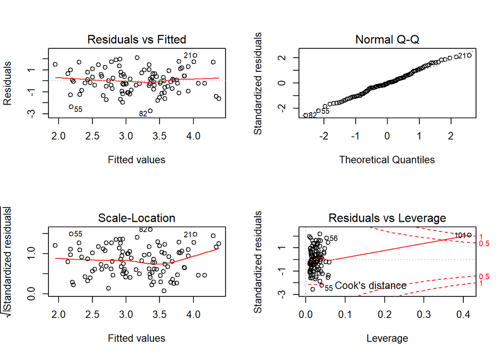

```r
par(mfrow=c(2,2))
plot(col_lm)
```

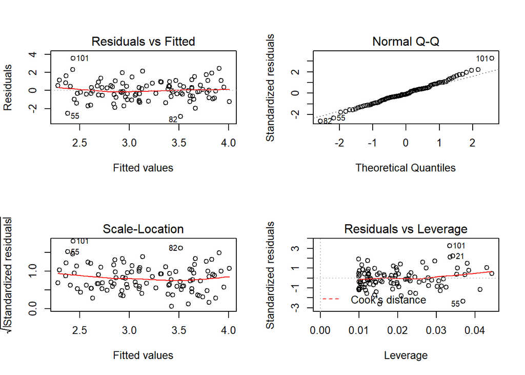

```r
par(mfrow=c(2,2))
plot(col_lm_2)
```

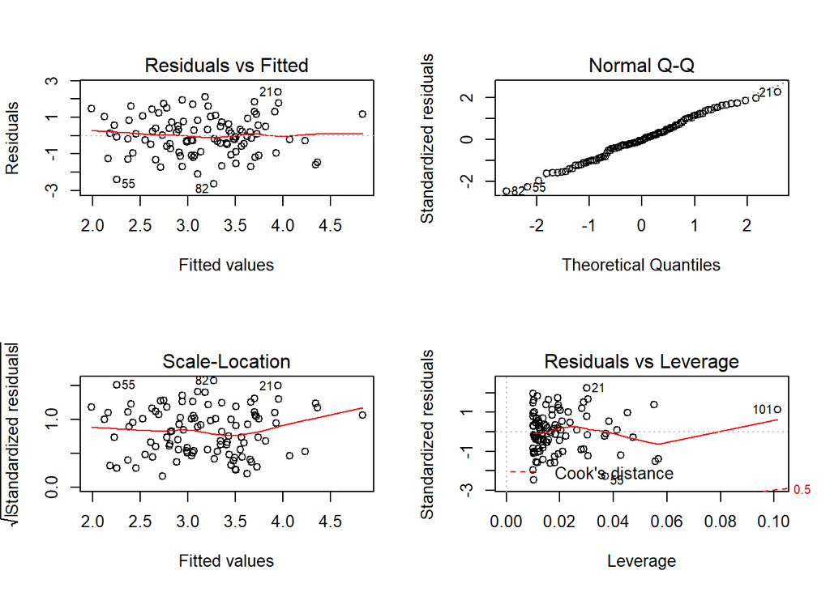

```r
par(mfrow=c(2,2))
plot(col_lm_3)
```

```r
library(MASS)
Boston
```

```r
names(Boston)
```

```
##  [1] "crim"    "zn"      "indus"   "chas"    "nox"     "rm"      "age"
##  [8] "dis"     "rad"     "tax"     "ptratio" "black"   "lstat"   "medv"
```

```r
lapply(c("zn", "indus", "nox", "chas", "rm", "age", "dis", "rad", "tax", "ptratio", "black", "lstat", "medv"),

       function(var) {

           formula    <- as.formula(paste("crim ~", var))
           boston_lm <- lm(formula, data = Boston)
           summary(boston_lm)
       })
```

```
## [[1]]
##
## Call:
## lm(formula = formula, data = Boston)
##
## Residuals:
##    Min     1Q Median     3Q    Max
## -4.429 -4.222 -2.620  1.250 84.523
##
## Coefficients:
##             Estimate Std. Error t value Pr(>|t|)
## (Intercept)  4.45369    0.41722  10.675  < 2e-16 ***
## zn          -0.07393    0.01609  -4.594 5.51e-06 ***
## ---
## Signif. codes:  0 '***' 0.001 '**' 0.01 '*' 0.05 '.' 0.1 ' ' 1
##
## Residual standard error: 8.435 on 504 degrees of freedom
## Multiple R-squared:  0.04019,    Adjusted R-squared:  0.03828
## F-statistic:  21.1 on 1 and 504 DF,  p-value: 5.506e-06
##
##
## [[2]]
##
## Call:
## lm(formula = formula, data = Boston)
##
## Residuals:
##     Min      1Q  Median      3Q     Max
## -11.972  -2.698  -0.736   0.712  81.813
##
## Coefficients:
##             Estimate Std. Error t value Pr(>|t|)
## (Intercept) -2.06374    0.66723  -3.093  0.00209 **
## indus        0.50978    0.05102   9.991  < 2e-16 ***
## ---
## Signif. codes:  0 '***' 0.001 '**' 0.01 '*' 0.05 '.' 0.1 ' ' 1
##
## Residual standard error: 7.866 on 504 degrees of freedom
## Multiple R-squared:  0.1653, Adjusted R-squared:  0.1637
## F-statistic: 99.82 on 1 and 504 DF,  p-value: < 2.2e-16
```

[output cut: 216 more lines]

```
##
## Residuals:
##    Min     1Q Median     3Q    Max
## -9.071 -4.022 -2.343  1.298 80.957
##
## Coefficients:
##             Estimate Std. Error t value Pr(>|t|)
## (Intercept) 11.79654    0.93419   12.63   <2e-16 ***
## medv        -0.36316    0.03839   -9.46   <2e-16 ***
## ---
## Signif. codes:  0 '***' 0.001 '**' 0.01 '*' 0.05 '.' 0.1 ' ' 1
##
## Residual standard error: 7.934 on 504 degrees of freedom
## Multiple R-squared:  0.1508, Adjusted R-squared:  0.1491
## F-statistic: 89.49 on 1 and 504 DF,  p-value: < 2.2e-16
```

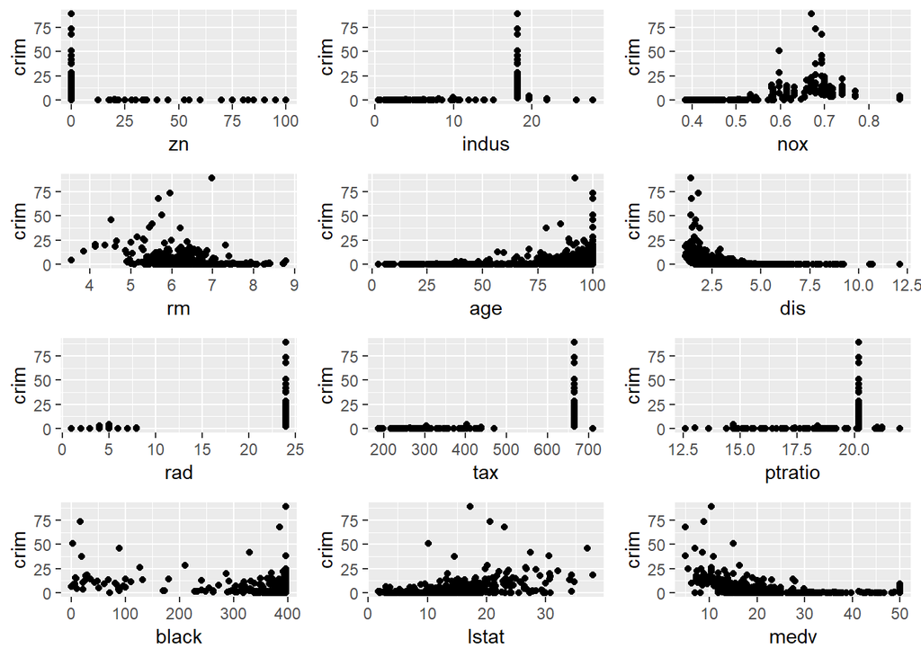

```r
p1 <- Boston %>% ggplot(aes(zn, crim)) + geom_point()
p2 <- Boston %>% ggplot(aes(indus, crim)) + geom_point()
p3 <- Boston %>% ggplot(aes(nox, crim)) + geom_point()
p4 <- Boston %>% ggplot(aes(rm, crim)) + geom_point()
p5 <- Boston %>% ggplot(aes(age, crim)) + geom_point()
p6 <- Boston %>% ggplot(aes(dis, crim)) + geom_point()
p7 <- Boston %>% ggplot(aes(rad, crim)) + geom_point()
p8 <- Boston %>% ggplot(aes(tax, crim)) + geom_point()
p9 <- Boston %>% ggplot(aes(ptratio, crim)) + geom_point()
p10 <- Boston %>% ggplot(aes(black, crim)) + geom_point()
p11 <- Boston %>% ggplot(aes(lstat, crim)) + geom_point()
p12 <- Boston %>% ggplot(aes(medv, crim)) + geom_point()
grid.arrange(p1, p2, p3, p4, p5, p6, p7, p8, p9, p10, p11, p12)
```

```r
full_crime_lm <- lm(crim ~ ., data = Boston)
summary(full_crime_lm)
```

```
##
## Call:
## lm(formula = crim ~ ., data = Boston)
##
## Residuals:
##    Min     1Q Median     3Q    Max
## -9.924 -2.120 -0.353  1.019 75.051
##
## Coefficients:
##               Estimate Std. Error t value Pr(>|t|)
## (Intercept)  17.033228   7.234903   2.354 0.018949 *
## zn            0.044855   0.018734   2.394 0.017025 *
## indus        -0.063855   0.083407  -0.766 0.444294
## chas         -0.749134   1.180147  -0.635 0.525867
## nox         -10.313535   5.275536  -1.955 0.051152 .
## rm            0.430131   0.612830   0.702 0.483089
## age           0.001452   0.017925   0.081 0.935488
## dis          -0.987176   0.281817  -3.503 0.000502 ***
## rad           0.588209   0.088049   6.680 6.46e-11 ***
## tax          -0.003780   0.005156  -0.733 0.463793
## ptratio      -0.271081   0.186450  -1.454 0.146611
## black        -0.007538   0.003673  -2.052 0.040702 *
## lstat         0.126211   0.075725   1.667 0.096208 .
## medv         -0.198887   0.060516  -3.287 0.001087 **
## ---
## Signif. codes:  0 '***' 0.001 '**' 0.01 '*' 0.05 '.' 0.1 ' ' 1
##
## Residual standard error: 6.439 on 492 degrees of freedom
## Multiple R-squared:  0.454,  Adjusted R-squared:  0.4396
## F-statistic: 31.47 on 13 and 492 DF,  p-value: < 2.2e-16
```

15b. In the full model, we see that only zn, dis, rad, black, and medv are significantly related to crime and we can reject the null hypothesis $\beta_{i}$ = 0.

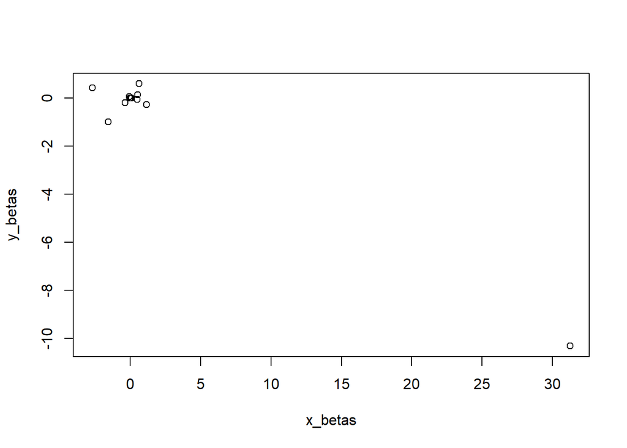

```r
#15c zn, indus, nox, rm, age, dis, rad, tax, ptratio, black, lstat, medv

indvar <- c("zn", "indus", "nox", "rm", "age", "dis", "rad", "tax", "ptratio", "black", "lstat", "medv")
x_betas <- lapply(indvar, function(dv) {
    boston_lm <- lm(crim ~ get(dv), data = Boston)
    boston_lm$coefficients[2]
})


y_betas <- full_crime_lm$coefficients
y_betas <- y_betas[-c(1,4)]

plot(x_betas, y_betas)
```

15c. Fewer of the variables are significantly related to crime in the full model than in the univariate regressions. As multicollinearity reduces power, this may be a reason fewer are significant. The plot also shows that the betas are not the same, which may be related to the interpretation of a multiple regression vs. a simple regression. In simple regression, we do not take other predictors into account and get the base average increase of a dependent variable given the predictor. in contrast, a multiple regression gives the average increase in the dependent variable *while holding the other variables constant.*

```r
#15d
lm_zn <- lm(crim ~ poly(zn, 3), data = Boston)




indvar <- c("zn", "indus", "nox", "rm", "age", "dis", "rad", "tax", "ptratio", "black", "lstat", "medv")
lapply(indvar, function(var) {
    boston_lm <- lm(crim ~ poly(get(var), 3), data = Boston)
    summary(boston_lm)

})
```

```
## [[1]]
##
## Call:
## lm(formula = crim ~ poly(get(var), 3), data = Boston)
##
## Residuals:
##    Min     1Q Median     3Q    Max
## -4.821 -4.614 -1.294  0.473 84.130
##
## Coefficients:
##                    Estimate Std. Error t value Pr(>|t|)
## (Intercept)          3.6135     0.3722   9.709  < 2e-16 ***
## poly(get(var), 3)1 -38.7498     8.3722  -4.628  4.7e-06 ***
## poly(get(var), 3)2  23.9398     8.3722   2.859  0.00442 **
## poly(get(var), 3)3 -10.0719     8.3722  -1.203  0.22954
## ---
## Signif. codes:  0 '***' 0.001 '**' 0.01 '*' 0.05 '.' 0.1 ' ' 1
##
## Residual standard error: 8.372 on 502 degrees of freedom
## Multiple R-squared:  0.05824,    Adjusted R-squared:  0.05261
## F-statistic: 10.35 on 3 and 502 DF,  p-value: 1.281e-06
##
##
## [[2]]
##
## Call:
## lm(formula = crim ~ poly(get(var), 3), data = Boston)
##
## Residuals:
##    Min     1Q Median     3Q    Max
## -8.278 -2.514  0.054  0.764 79.713
##
## Coefficients:
##                    Estimate Std. Error t value Pr(>|t|)
## (Intercept)           3.614      0.330  10.950  < 2e-16 ***
## poly(get(var), 3)1   78.591      7.423  10.587  < 2e-16 ***
## poly(get(var), 3)2  -24.395      7.423  -3.286  0.00109 **
## poly(get(var), 3)3  -54.130      7.423  -7.292  1.2e-12 ***
## ---
## Signif. codes:  0 '***' 0.001 '**' 0.01 '*' 0.05 '.' 0.1 ' ' 1
```

[output cut: 219 more lines]

```
##     Min      1Q  Median      3Q     Max
## -24.427  -1.976  -0.437   0.439  73.655
##
## Coefficients:
##                    Estimate Std. Error t value Pr(>|t|)
## (Intercept)           3.614      0.292  12.374  < 2e-16 ***
## poly(get(var), 3)1  -75.058      6.569 -11.426  < 2e-16 ***
## poly(get(var), 3)2   88.086      6.569  13.409  < 2e-16 ***
## poly(get(var), 3)3  -48.033      6.569  -7.312 1.05e-12 ***
## ---
## Signif. codes:  0 '***' 0.001 '**' 0.01 '*' 0.05 '.' 0.1 ' ' 1
##
## Residual standard error: 6.569 on 502 degrees of freedom
## Multiple R-squared:  0.4202, Adjusted R-squared:  0.4167
## F-statistic: 121.3 on 3 and 502 DF,  p-value: < 2.2e-16
```

15d. All of the models significantly predicted crime, and the Adjusted R-squared of the polynomial models is also generally greater than for the simple linear regression.